# Statistical power of the EucFACE study design

The experimental design of the EucFACE study has limited statistical power when analysing only the fixed effects of elevated or ambient CO2 at the level of independent experimental units (three replicates per treatment). However, the large area of each of the rings (~500 m2) and likely spatial heterogeneity at the site allows for the opportunity to perform multiple measurements within each experimental unit and accurately estimate within-ring variation, thus allowing for more precise estimates of between-ring (and between-treatment) variation.

The hierarchical nature of such a design complicates the estimation of statistical power, since such power will depend on estimation of random effect sizes in addition to fixed effect sizes and residual variation. Gelman and Hill (2007, Data Analysis Using Regression and Multilevel/Hierarchical Models, pp. 449-454) describe a simulation approach for estimating power in hierarchical sampling designs. This approach was used to simulate plant responses (foliar N and P concentration, photosynthesis) and soil nutrient responses (extractable N and P, mineralised N and P) to elevated and ambient CO2, using pretreatment measures to estimate variation at the within-tree/plot, within-ring, and between-ring levels.

## Response variables: Foliar N, P

For leaves collected prior to the experiment, over half of the variation in N concentration was explained by the identity of the tree from which the leaves were collected, while no variation was explained by the identity of the ring in which the tree was located (see the ‘Random effects’ block for ‘mod.N’).

```r
mod.N<-lmer(percentN~1+(1|Ring/Tree),data=GEdata)
mod.N
```

```
## Linear mixed model fit by REML ['lmerMod']
## Formula: percentN ~ 1 + (1 | Ring/Tree)
##    Data: GEdata
## REML criterion at convergence: -3.7217
## Random effects:
##  Groups    Name        Std.Dev.
##  Tree:Ring (Intercept) 0.1727
##  Ring      (Intercept) 0.0000
##  Residual              0.1601
## Number of obs: 32, groups:  Tree:Ring, 17; Ring, 6
## Fixed Effects:
## (Intercept)
##        1.84
```

Phosphorus concentration was better explained by tree identity than ring identity (see the ‘Random effects’ block for ‘mod.P’). However, phosphorus concentration was only estimated from multiple leaves on three trees; this makes it difficult to be certain that the variation has been partitioned correctly to ring identity and tree identity.

```r
mod.P<-lmer(percentP~1+(1|Ring/Tree),data=GEdata)
mod.P
```

```
## Linear mixed model fit by REML ['lmerMod']
## Formula: percentP ~ 1 + (1 | Ring/Tree)
##    Data: GEdata
## REML criterion at convergence: -116.3778
## Random effects:
##  Groups    Name        Std.Dev.
##  Tree:Ring (Intercept) 0.004368
##  Ring      (Intercept) 0.002205
##  Residual              0.009344
## Number of obs: 20, groups:  Tree:Ring, 17; Ring, 6
## Fixed Effects:
## (Intercept)
##     0.08513
```

These results suggest that estimating foliar nutrient content by sampling leaves from a single tree within each ring is not likely to provide a reliable estimate of the response of trees within each ring. This was tested by generating simulated responses at range of effect sizes, numbers of trees sampled per ring, and numbers of leaves sampled per tree (1000 simulations per combination). Responses were simulated based on the analysis of foliar N concentrations using the following formula,

$y_{ij} = \beta x + b_i + \epsilon_{ij},$ $b_i \sim N(0, \sigma^2_b), \epsilon_{ij} \sim N(0, \sigma^2),$

where $y_{ij}$ is the measured concentration of N for leaf $j$ on tree $i$, $\beta$ is the simulated effect size associated with the CO2 treatment, $b_i$ is the random intercept for tree $i$, and $\epsilon_{ij}$ is the residual error. Variances ($\sigma^2_b$ and $\sigma^2$) were taken from the random effects block of ‘mod.N’.

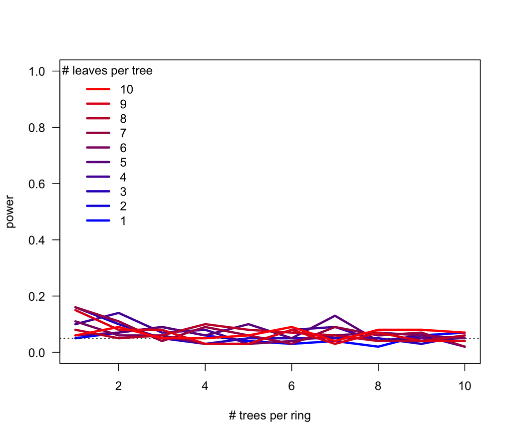

**Type I error rate associated with leaf nutrient content, estimated from the observed frequency of significant CO2 effects when the actual CO2 effect is nil.**

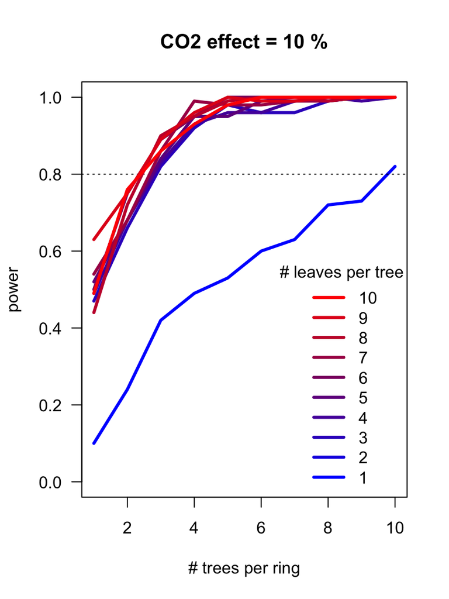

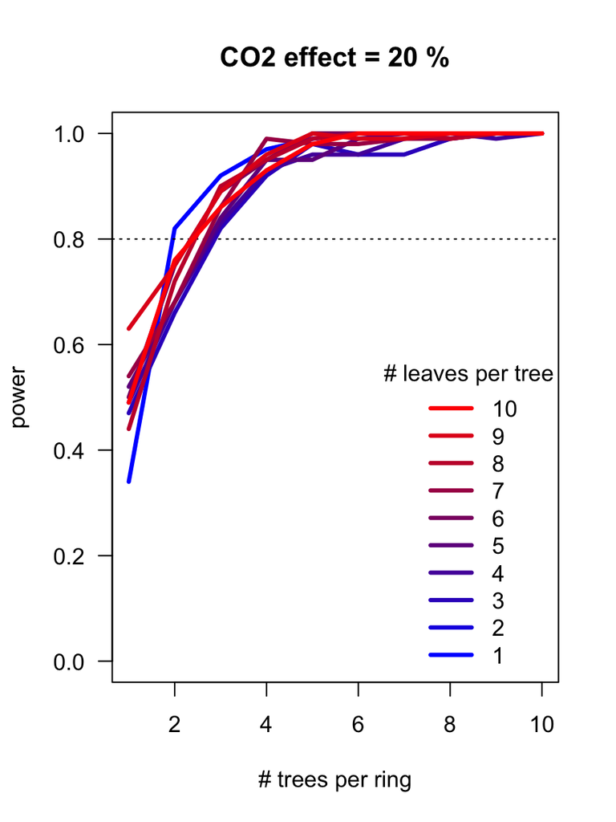

**Power to detect a 10 % or 20 % increase in leaf nutrient concentration, while varying the number of trees sampled per ring and leaves sampled per tree.**

Increasing sampling intensity per tree had little effect on statistical power, with the exception of detecting small effect sizes and sampling only one leaf per tree. Reasonable statistical power (80 %) was achieved by sampling leaves from at least three trees per ring.

## Response variable: Photosynthetic rate

Prior to the experiment, close to half of the variation in photosynthetic rate was explained by the identity of the ring from which the measurements were taken, while no variation was explained by the identity of the tree (see the ‘Random effects’ block for ‘mod.Anet’).

```r
mod.Anet<-lmer(Anet_390~1+(1|Ring/Tree),data=GEdata)
mod.Anet
```

```
## Linear mixed model fit by REML ['lmerMod']
## Formula: Anet_390 ~ 1 + (1 | Ring/Tree)
##    Data: GEdata
## REML criterion at convergence: 155.0248
## Random effects:
##  Groups    Name        Std.Dev.
##  Tree:Ring (Intercept) 0.000
##  Ring      (Intercept) 2.033
##  Residual              2.466
## Number of obs: 32, groups:  Tree:Ring, 17; Ring, 6
## Fixed Effects:
## (Intercept)
##       16.02
```

As for foliar P, the number of samples taken per tree was low so these estimates may potentially misrepresent any effect of tree identity. In any case, the large amount of between-ring variation is a concern since this may introduce variation that masks any effect of elevated CO2. This was tested by generating simulated responses at range of effect sizes and numbers of measurements taken per ring (1000 simulations per combination). Responses were simulated using the same formula as above with the exception that $y_{ij}$ is the measured photosynthetic rate for leaf $j$ in ring $i$ (regardless of the tree it was measured on), $b_i$ is the random intercept for ring $i$, and variances ($\sigma^2_b$ and $\sigma^2$) were taken from the random effects block of ‘mod.Anet’.

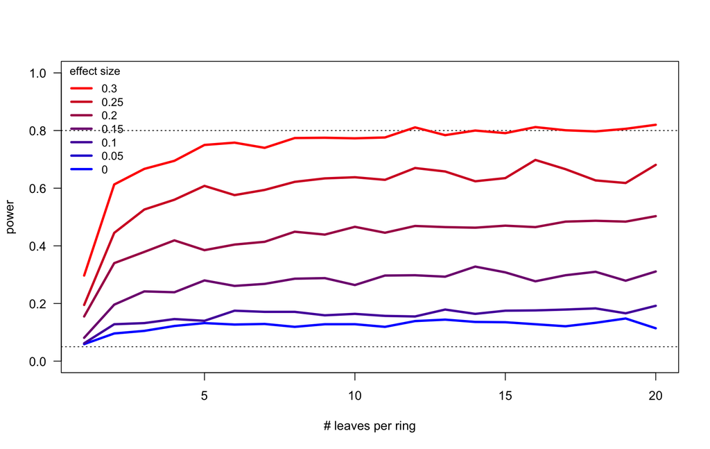

**Statistical power associated with an up to 30 % increase in leaf photosynthetic rate while varying the number of leaves sampled per ring.**

The experiment is limited to six rings (three per treatment), but we can estimate the effects of increasing the number of replicates on power through further simulation.

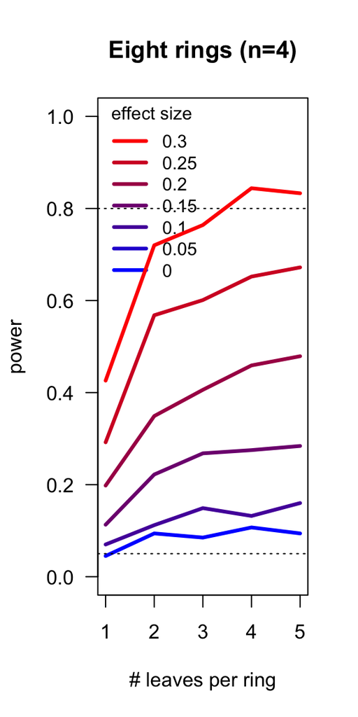

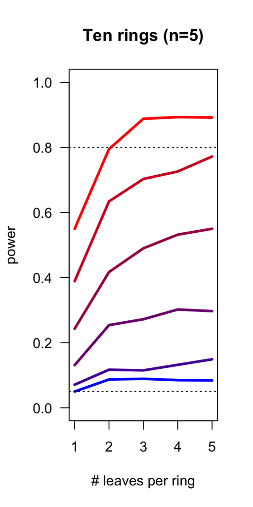

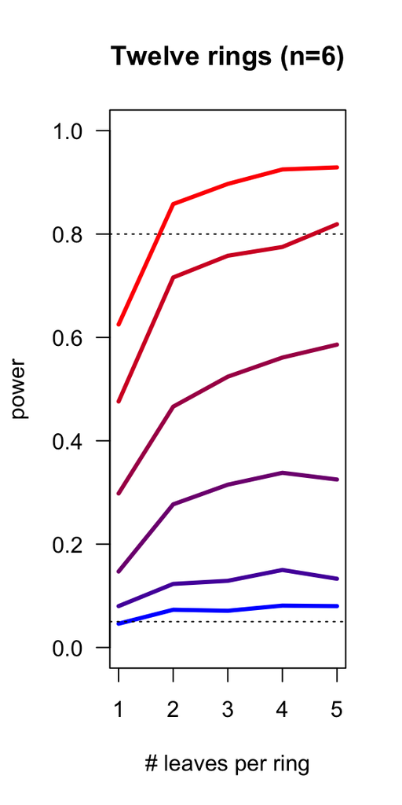

**Statistical power associated with an up to 30 % increase in leaf photosynthetic rate while varying the number of leaves sampled per ring and the number of rings established per treatment.**

While power increases with in increase in the number of rings per CO2 treatment, this increase is marginal (approx. 10 % with a doubling of the number of rings).

## Response variables: soil N, P (extractable concentrations, ion exchange resins)

The effect of sampling from multiple soil plots within each ring on the ability to detect differences between treatments was tested by generating simulated responses at range of effect sizes and numbers of measurements taken per ring (1000 simulations per combination). Responses were simulated using the following formula,

$y_{ijk} = \beta x + b_i + b_{ij} + \epsilon_{ijk},$ $b_i \sim N(0, \sigma^2_{b1}), b_{ij} \sim N(0, \sigma^2_{b2}), \epsilon_{ijk} \sim N(0, \sigma^2),$

where $y_{ijk}$ is the measured soil nutrient concentration for plot $j$ in ring $i$ (after log10 transformation), $b_i$ is the random intercept for ring $i$, $b_ij$ is the random intercept for plot $j$ nested within ring $i$, and variances and residual error defined as above. Different levels of variances were tested for each of $\sigma^2_b$ and $\sigma^2$, taken from the random effects blocks across each of the models describing soil nutrient concentrations. ‘Sampling date’ was not explicitly modelled; instead this is implicitly represented in the estimate of $b_ij$.

## Nitrate

Most variation in nitrate concentrations was accounted for by ring identity (approx. 35 %) and plot identity (approx. 25 %); see the ‘Random effects’ block for ‘mod.NO3extr’ and ‘mod.NO3iems’). Residual variation was much greater in extractable nitrate than for concentrations in ion-exchange resins (relative to estimated intercept), leading to very low levels of power.

```
## Linear mixed model fit by REML ['lmerMod']
## Formula: no ~ 1 + (1 | Date) + (1 | Ring/Plot)
##    Data: extracts
## REML criterion at convergence: 18.6432
## Random effects:
##  Groups    Name        Std.Dev.
##  Plot:Ring (Intercept) 0.1408
##  Ring      (Intercept) 0.1805
##  Date      (Intercept) 0.3167
##  Residual              0.2172
## Number of obs: 48, groups:  Plot:Ring, 24; Ring, 6; Date, 2
## Fixed Effects:
## (Intercept)
##      0.1902
```

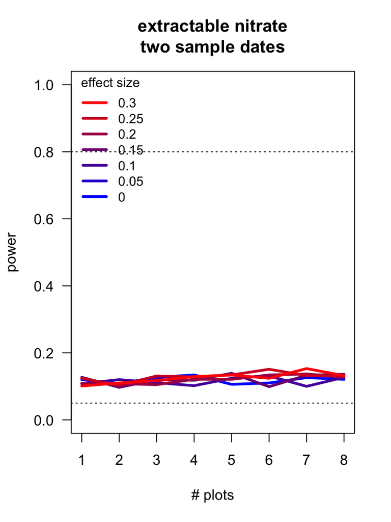

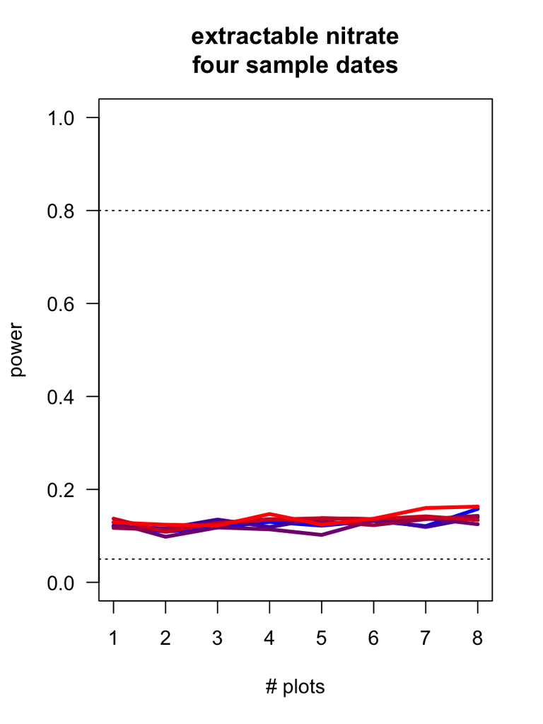

```
## Linear mixed model fit by REML ['lmerMod']
## Formula: Nitrate ~ 1 + (1 | Date) + (1 | Ring/Plot)
##    Data: iems
## REML criterion at convergence: 71.3683
## Random effects:
##  Groups    Name        Std.Dev.
##  Plot:Ring (Intercept) 0.1682
##  Ring      (Intercept) 0.2264
##  Date      (Intercept) 0.1788
##  Residual              0.2372
## Number of obs: 192, groups:  Plot:Ring, 48; Ring, 6; Date, 4
## Fixed Effects:
## (Intercept)
##       2.726
```

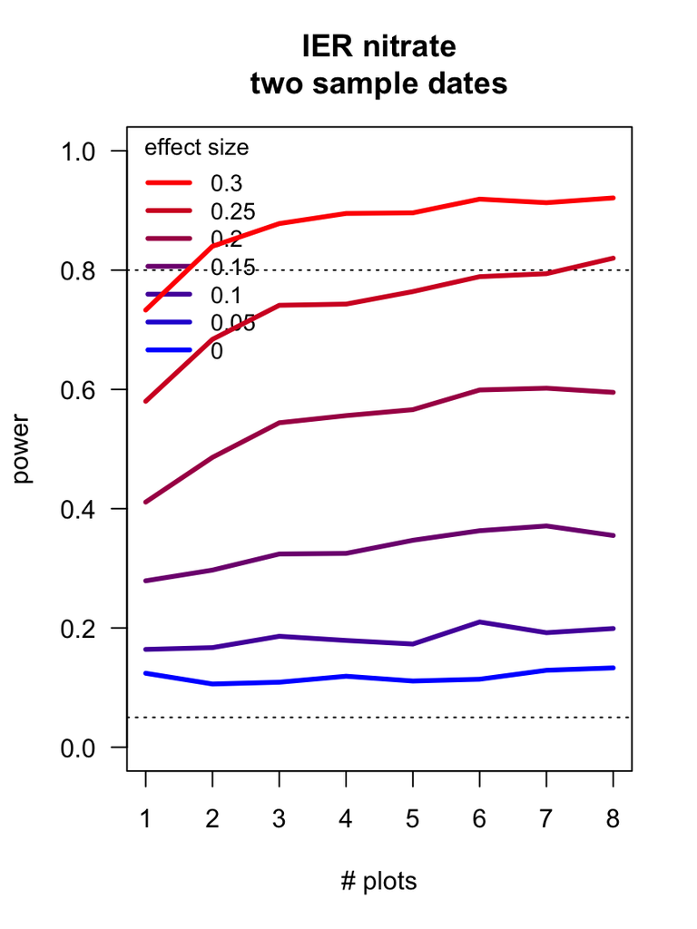

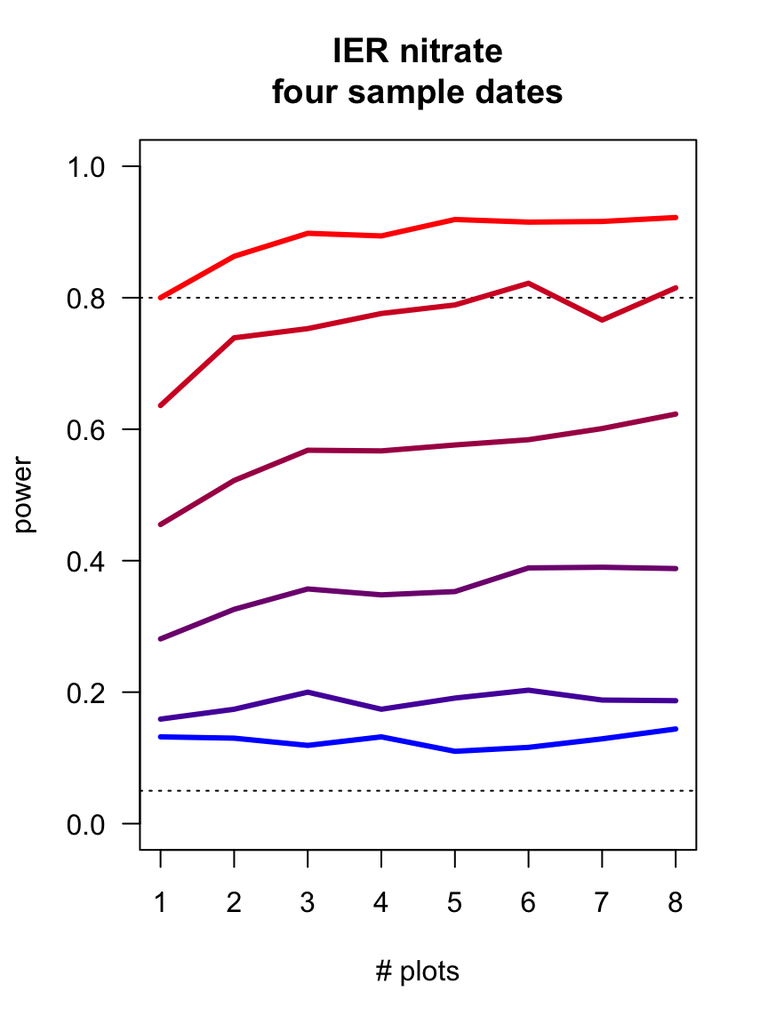

## Ammonium

Ring identity accounted for a similar amount of variation in ammonium concentrations as for nitrate, but plot identity accounted for less variation (approx. 5-20 %); see the ‘Random effects’ block for ‘mod.NH4extr’ and ‘mod.NH4iems’). Power was higher for extractable ammonium due to the comparably low level of residual variation (relative to intercept).

```
## Linear mixed model fit by REML ['lmerMod']
## Formula: nh ~ 1 + (1 | Date) + (1 | Ring/Plot)
##    Data: extracts
## REML criterion at convergence: -69.9664
## Random effects:
##  Groups    Name        Std.Dev.
##  Plot:Ring (Intercept) 0.01288
##  Ring      (Intercept) 0.05907
##  Date      (Intercept) 0.18974
##  Residual              0.09700
## Number of obs: 48, groups:  Plot:Ring, 24; Ring, 6; Date, 2
## Fixed Effects:
## (Intercept)
##       1.035
```

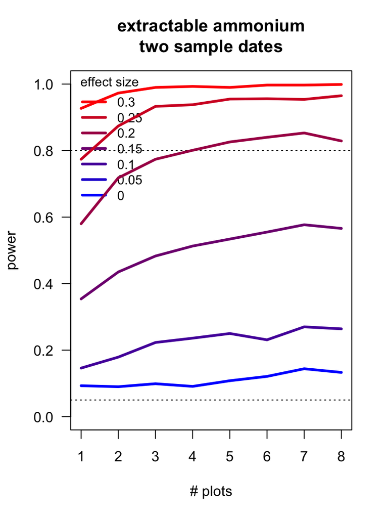

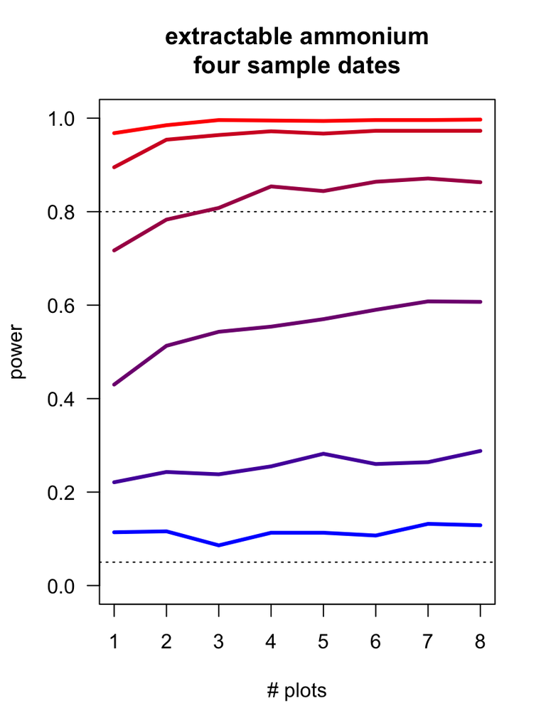

```
## Linear mixed model fit by REML ['lmerMod']
## Formula: Ammonium ~ 1 + (1 | Date) + (1 | Ring/Plot)
##    Data: iems
## REML criterion at convergence: 205.0134
## Random effects:
##  Groups    Name        Std.Dev.
##  Plot:Ring (Intercept) 0.1514
##  Ring      (Intercept) 0.2314
##  Date      (Intercept) 0.2773
##  Residual              0.3620
## Number of obs: 192, groups:  Plot:Ring, 48; Ring, 6; Date, 4
## Fixed Effects:
## (Intercept)
##       1.802
```

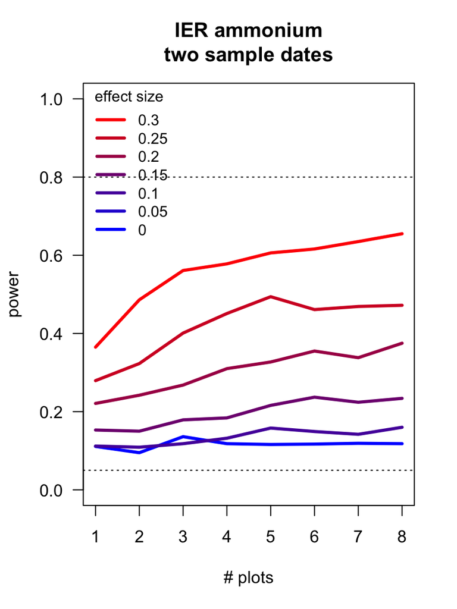

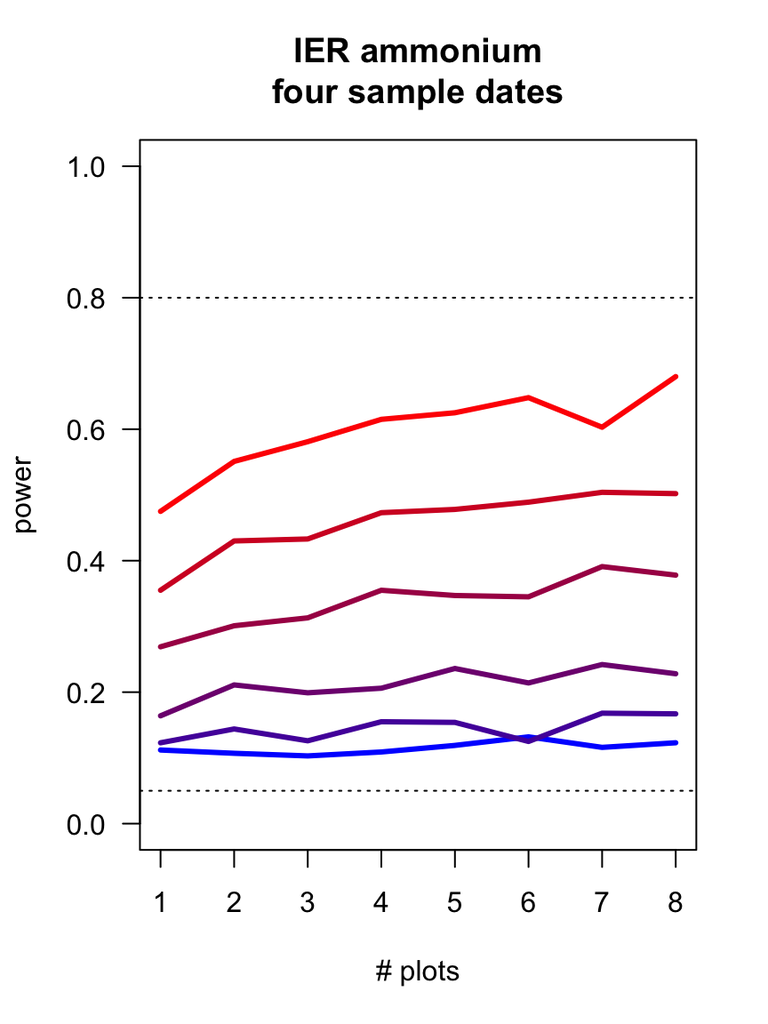

## Phosphate

```
## Linear mixed model fit by REML ['lmerMod']
## Formula: po ~ 1 + (1 | Date) + (1 | Ring/Plot)
##    Data: extracts
## REML criterion at convergence: -56.7313
## Random effects:
##  Groups    Name        Std.Dev.
##  Plot:Ring (Intercept) 0.00000
##  Ring      (Intercept) 0.02049
##  Date      (Intercept) 0.03846
##  Residual              0.12408
## Number of obs: 48, groups:  Plot:Ring, 24; Ring, 6; Date, 2
## Fixed Effects:
## (Intercept)
##      0.2349
```

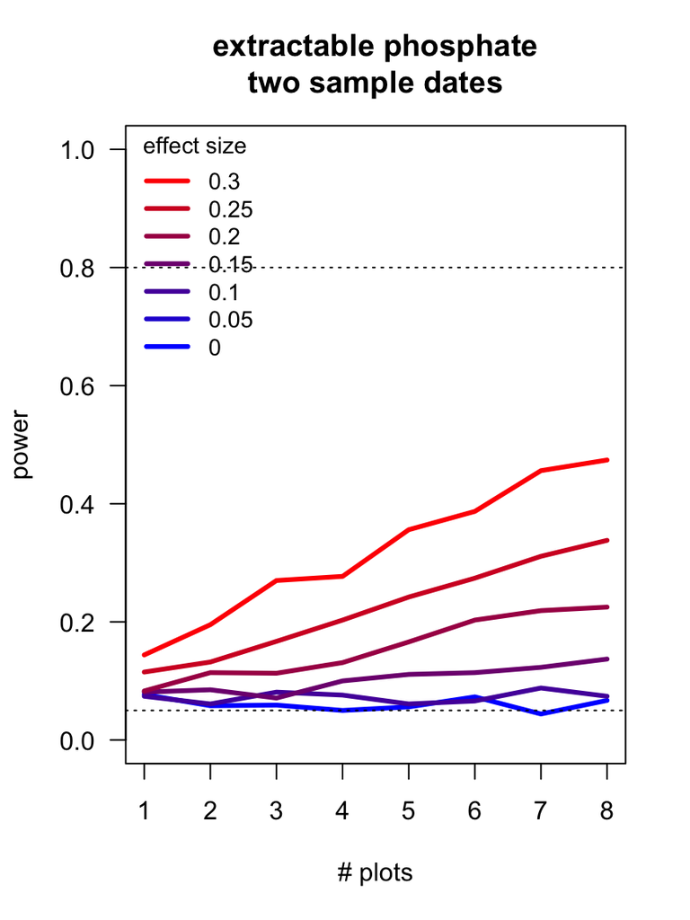

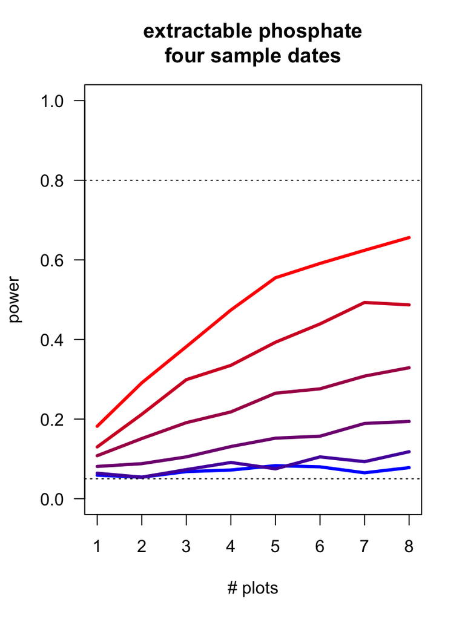

```
## Linear mixed model fit by REML ['lmerMod']
## Formula: Phosphate ~ 1 + (1 | Date) + (1 | Ring/Plot)
##    Data: iems
## REML criterion at convergence: 176.5531
## Random effects:
##  Groups    Name        Std.Dev.
##  Plot:Ring (Intercept) 8.340e-08
##  Ring      (Intercept) 1.643e-01
##  Date      (Intercept) 3.086e-01
##  Residual              3.586e-01
## Number of obs: 192, groups:  Plot:Ring, 48; Ring, 6; Date, 4
## Fixed Effects:
## (Intercept)
##      0.3078
```

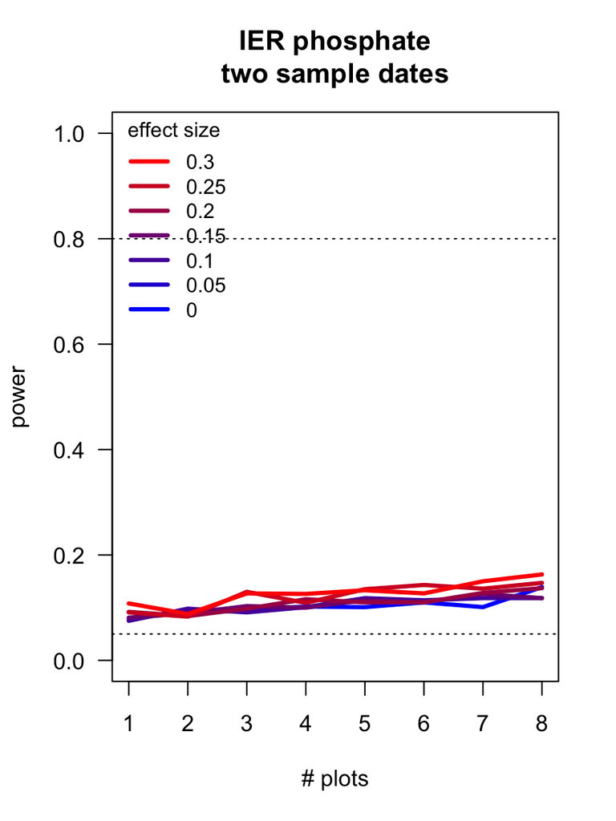

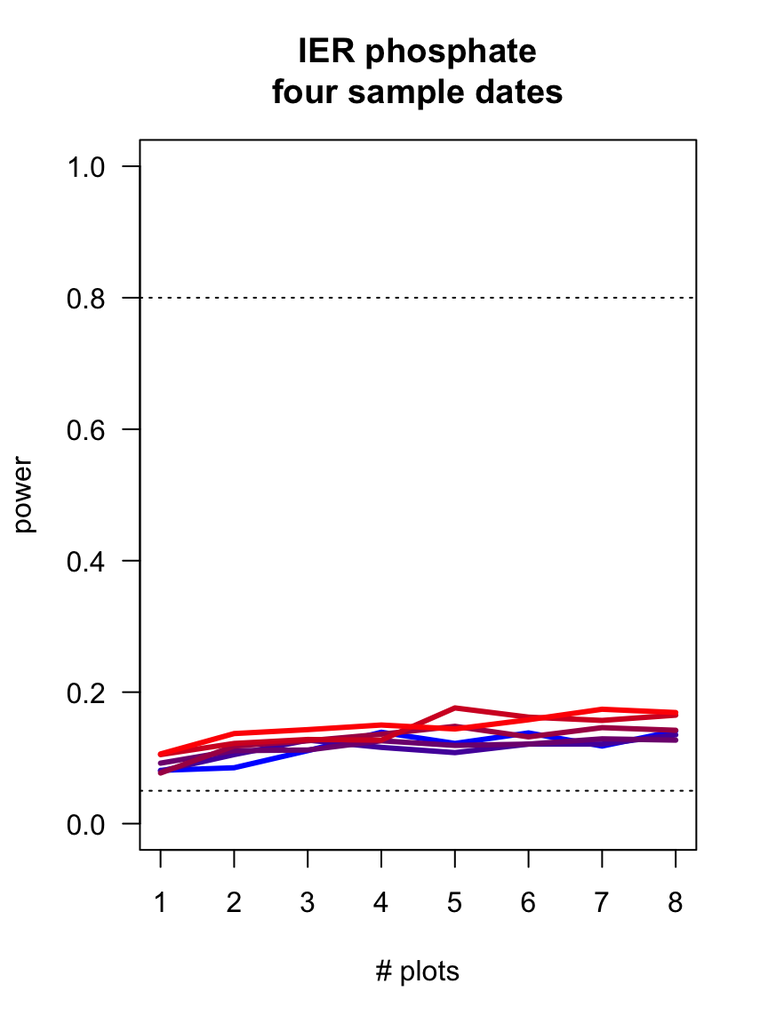

So the ability to detect treatment effects of up to 30% varied depending on the nutrient measured and the method used for measurement. Power to detect larger effect sizes was quite high in some cases, given the level of replication within each ring that is currently in place. Where power was low, this appeared to be due to a high level of unexplained variation in addition to (or due to, in some cases?) low partitioning of variation to random effects. For these, I did not repeat the exercise of increasing the number of rings, as for photosynthetic rate, as I suspect that the result will be similar or even less of an increase in power (due to greater variance estimates associated with random effects and/or a higher estimate of mean to residual variance for the photosynthesis data).